# Project Report

Group 3

December 9, 2018

### Executive Summary:

We analyzed Wine Review dataset from Kaggles.com to extract meaningful marketing insights from it to help online wine platform startup to navigate in the complicated market. We utilized ggplot library to create intuitive and informative visualizations to help identifying pattern and relationship between wine variables and reviewed scores. We further utilized linear regression analysis to further investigate the relationship we identified, and kept optimizing the model with feature engineering and natural language processing techniques. With the accurate model we trained, our client can not only determine popularity or quality of each product, but also predict scores when it is not available to provide customers with helpful information.

### Motivation and Background:

Our client is an Online e-commerce platform startup who sells wine. Our client has a dataset of their historical reviews, the Wine Review dataset. In order to maximize revenue and profit, our client would like to carry products with higher scores. When new products coming in, they might not have review scores available, but the platform still needs to provide meaningful recommendation for customers.

Our client want to know what types of wine are best-sellers with highest scores. Our client also want to be able to predict wine scores based on other variables.

### Data description:

The list of variables are as follows: Country: The country that the wine is from. Description: A few sentences from a sommelier describing the wine’s taste, smell, look, feel, etc. Designation: The vineyard within the winery where the grapes that made the wine are from. Points: The number of points WineEnthusiast rated the wine on a scale of 1-100 (though they say they only post reviews for wines that score >=80). Price: The cost for a bottle of the wine. Province: The province or state that the wine is from. Region 1: The wine growing area in a province or state (ie Napa). Region 2: Sometimes there are more specific regions specified within a wine growing area (ie Rutherford inside the Napa Valley), but this value can sometimes be blank. Taster Name: Name of the person who tasted and reviewed the wine. Taster twitter handle: Twitter handle for the person who tasted and reviewed the wine. Title: The title of the wine review, which often contains the vintage if you’re interested in extracting that feature. Variety: The type of grapes used to make the wine. Winery: The winery that made the wine.

### Exploratory Analysis

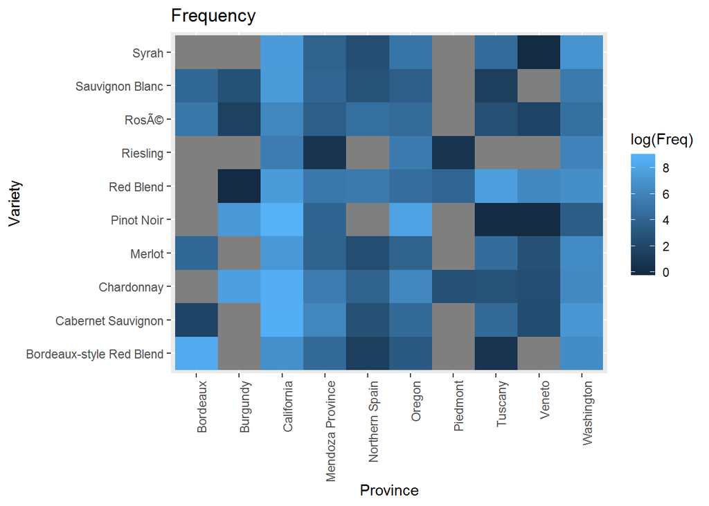

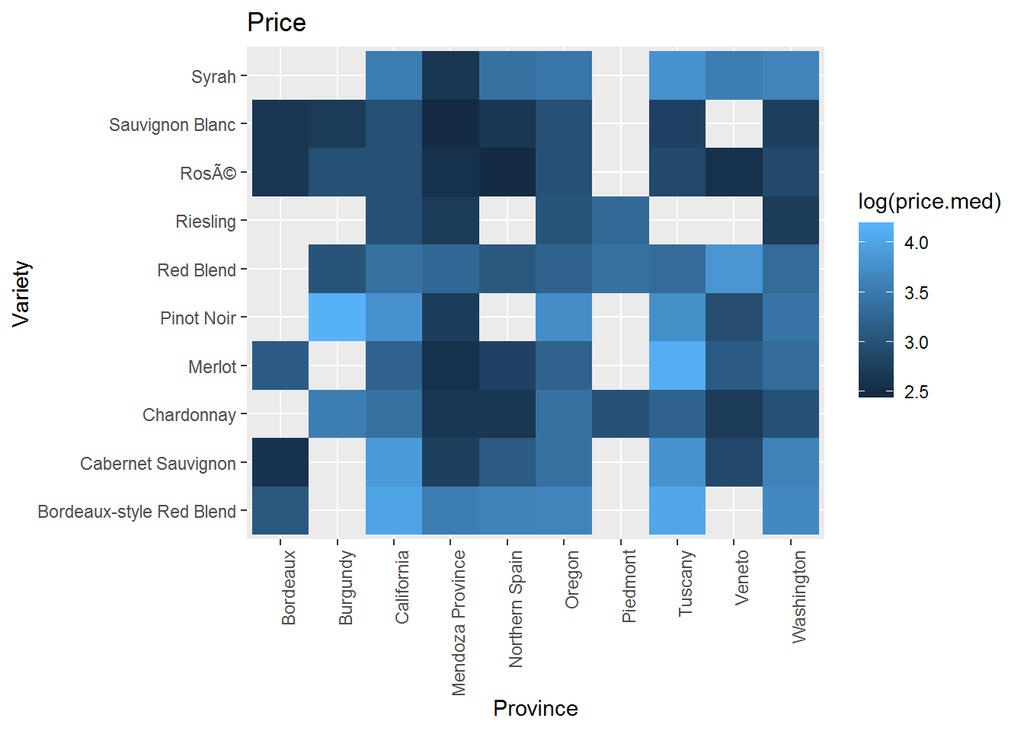

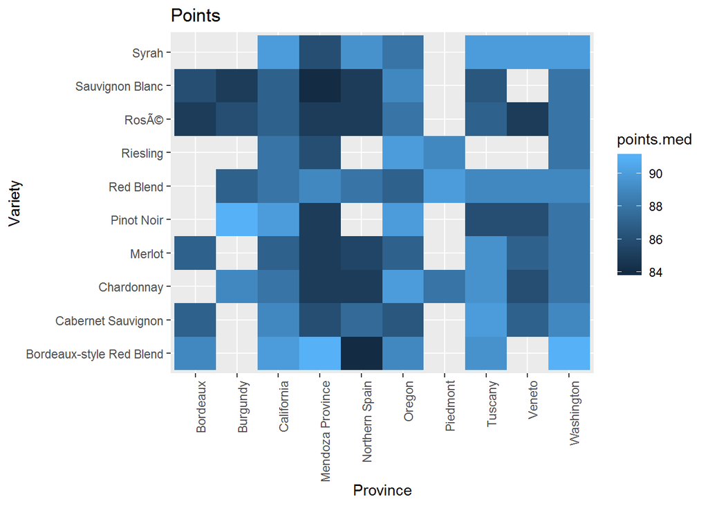

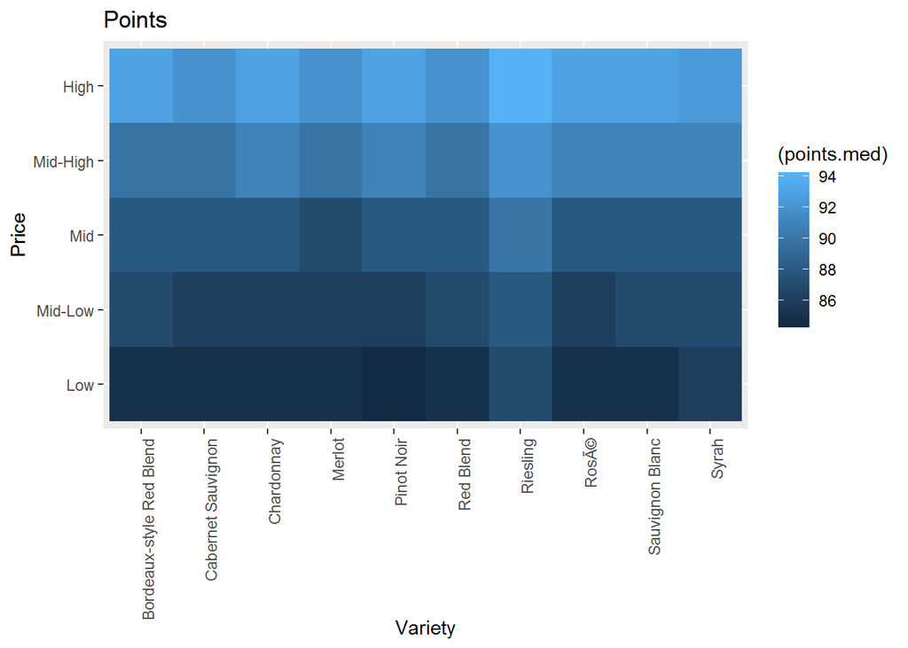

From heatmap we can intuitively see the relationship between variety, origin and points. In general, california have good quality wines, and the higher the price is, the higher the quality. This holds true for most of the products.

### Modeling

[output not shown]

```
##
## Call:
## lm(formula = points ~ country + price + province + taster_name +
##     variety, data = wine)
##
## Residuals:
##     Min      1Q  Median      3Q     Max
## -74.714  -1.583   0.039   1.688   9.432
##
## Coefficients: (46 not defined because of singularities)
##                                              Estimate Std. Error t value
## (Intercept)                                86.4790512  2.6257593  32.935
## countryArmenia                              0.5473067  2.4676739   0.222
## countryAustralia                            3.0431615  0.2918329  10.428
## countryAustria                              0.9078875  0.5863244   1.548
## countryBosnia and Herzegovina              -2.2228060  2.9642388  -0.750
## countryBrazil                              -0.7202974  1.1022379  -0.653
## countryBulgaria                            -0.6631752  0.4207544  -1.576
## countryCanada                               0.7816956  0.3504480   2.231
## countryChile                                3.2963458  1.0058110   3.277
## countryChina                               -0.4791545  2.4863386  -0.193
## countryCroatia                             -2.4441758  1.1343200  -2.155
## countryCyprus                              -0.4712829  2.4593711  -0.192
## countryCzech Republic                      -1.4820430  0.9410438  -1.575
## countryEngland                              1.7076519  0.3970567   4.301
## countryFrance                               0.7091548  0.2616423   2.710
## countryGeorgia                             -0.0862262  0.5814005  -0.148
## countryGermany                              0.3292507  0.6821665   0.483
## countryGreece                               1.2428959  1.7503388   0.710
## countryHungary                             -0.6353991  0.6259703  -1.015
## countryIndia                                1.3277206  0.8855202   1.499
## countryIsrael                               0.2659488  0.5277565   0.504
## countryItaly                                1.5890636  0.2637969   6.024
## countryLebanon                              0.3327852  0.7619782   0.437
## countryLuxembourg                          -0.7231078  1.0691273  -0.676
## countryMacedonia                           -0.5235638  0.9118787  -0.574
## countryMexico                              -0.8467790  0.3381372  -2.504
## countryMoldova                             -1.4266262  0.4973444  -2.868
## countryMorocco                             -0.0613732  0.6637434  -0.092
## countryNew Zealand                          2.0639269  2.4556496   0.840
```

[output cut: 2221 more lines]

```
## varietyXinomavro                           0.448846
## varietyXynisteri                           0.462661
## varietyYapincak                            0.555572
## varietyZibibbo                             0.605188
## varietyZierfandler                         0.887649
## varietyZierfandler-Rotgipfler              0.745973
## varietyZinfandel                           0.862311
## varietyZlahtina                                  NA
## varietyZweigelt                            0.910278
## ---
## Signif. codes:  0 '***' 0.001 '**' 0.01 '*' 0.05 '.' 0.1 ' ' 1
##
## Residual standard error: 2.443 on 95337 degrees of freedom
## Multiple R-squared:  0.3226, Adjusted R-squared:  0.3149
## F-statistic: 41.95 on 1082 and 95337 DF,  p-value: < 2.2e-16
```

```
##
## Call:
## lm(formula = points ~ log(price) + province + taster_name + variety,
##     data = wine)
##
## Residuals:
##      Min       1Q   Median       3Q      Max
## -13.8412  -1.3513   0.1091   1.4818   7.7070
##
## Coefficients: (5 not defined because of singularities)
##                                             Estimate Std. Error t value
## (Intercept)                                77.293281   2.360992  32.738
## log(price)                                  2.827878   0.013215 213.993
## provinceÃ…Â½upa                            -1.549905   0.990994  -1.564
## provinceAchaia                              0.914725   1.186057   0.771
## provinceAconcagua Costa                     2.562767   0.675761   3.792
## provinceAconcagua Valley                    2.702614   0.572483   4.721
## provinceAegean                              0.165192   0.731855   0.226
## provinceÃƒâ\200“sterreichischer Perlwein      -1.571560   1.200365  -1.309
## provinceÃƒâ\200“sterreichischer Sekt           0.261945   0.588219   0.445
## provinceAgioritikos                         1.369982   1.338252   1.024
## provinceAhr                                 0.954742   0.937764   1.018
## provinceAlenquer                            2.556640   1.023809   2.497
## provinceAlentejano                          1.576979   0.532093   2.964
## provinceAlentejo                            1.895243   0.554620   3.417
## provinceAlenteo                             2.044466   2.211216   0.925
## provinceAlgarve                             0.416756   0.888902   0.469
## provinceAlsace                              1.118310   0.521677   2.144
## provinceAmerica                             0.948635   0.576823   1.645
## provinceAmindeo                            -3.045329   2.249514  -1.354
## provinceAmyndeon                           -0.315655   1.917911  -0.165
## provinceAndalucia                           3.692257   0.638535   5.782
## provinceAnkara                              0.144162   1.157255   0.125
## provinceApalta                              2.442345   0.819274   2.981
## provinceArcadia                            -0.638696   2.320712  -0.275
## provinceArizona                            -2.279012   0.827946  -2.753
## provinceArmenia                             1.548364   2.213531   0.699
## provinceAtalanti Valley                     2.927295   0.765550   3.824
## provinceAtlantida                           1.174667   1.104760   1.063
## provinceAttica                              0.896831   1.174417   0.764
```

[output cut: 2139 more lines]

```
## varietyXinomavro                           0.561351
## varietyXynisteri                           0.378849
## varietyYapincak                            0.564824
## varietyZibibbo                             0.746596
## varietyZierfandler                         0.988860
## varietyZierfandler-Rotgipfler              0.666249
## varietyZinfandel                           0.874715
## varietyZlahtina                                  NA
## varietyZweigelt                            0.901011
## ---
## Signif. codes:  0 '***' 0.001 '**' 0.01 '*' 0.05 '.' 0.1 ' ' 1
##
## Residual standard error: 2.146 on 95337 degrees of freedom
## Multiple R-squared:  0.4773, Adjusted R-squared:  0.4713
## F-statistic: 80.44 on 1082 and 95337 DF,  p-value: < 2.2e-16
```

Model 2: Selected varaibles with log transformed price

## Word count analysis on how many words are in each review

```
##    Min. 1st Qu.  Median    Mean 3rd Qu.    Max.
##    3.00   33.00   40.00   40.75   48.00  135.00
```

#### Description with the highest wordcount

```
## [1] This very fine Cabernet wants a little time in the cellar. Right now, it's tight in tannins, with some acidic bitterness in the finish. The flavors are of black currants and smoky new oak. The Morisoli Vineyard has been home to very good, ageable bottlings from the likes of Sequoia Grove and …
## 119955 Levels: "Chremisa," the ancient name of Krems, is commemorated in this wine that comes from Krems vineyards. It has tight, tangy apple-driven acidity, with a bright, light, citrusy character. Not for aging. ...
```

#### Description with the lowest wordcount

```
## [1] Imported by Kobrand.
## 119955 Levels: "Chremisa," the ancient name of Krems, is commemorated in this wine that comes from Krems vineyards. It has tight, tangy apple-driven acidity, with a bright, light, citrusy character. Not for aging. ...
```

### Wordcount distribution

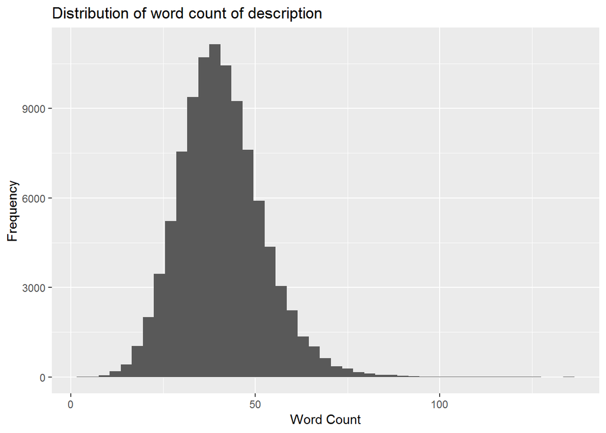

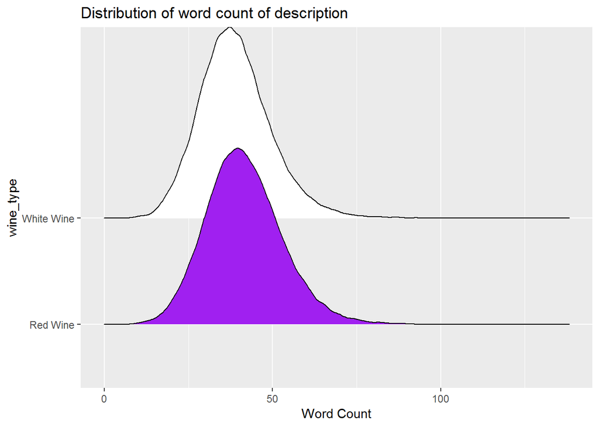

As displayed, there tend to be more words written to describe red wine as there are for white wines.

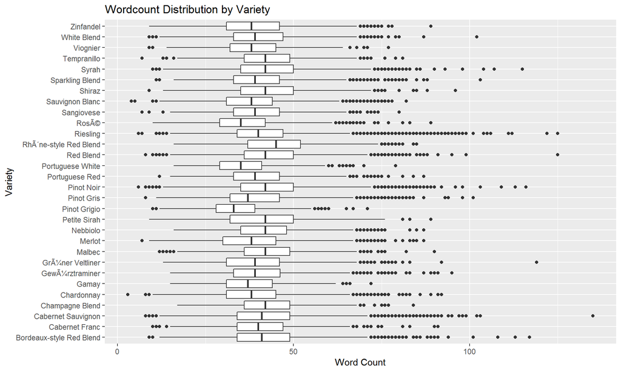

There is a fair bit of variability between the different varieties and the description word count. Pinot Grigio has the lowest median of the white wines, while Rose has the lowest of the red wines.

#### Is there a correlation between word count and the score?

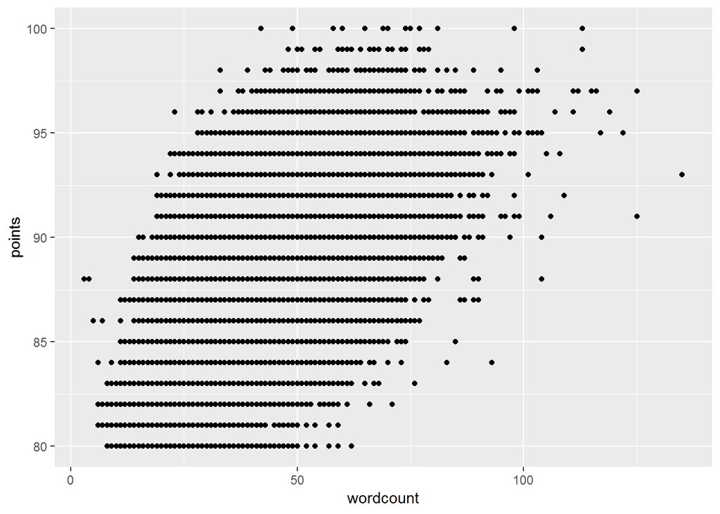

```
## [1] 0.5450367
```

There is a positive correlation between the number of words used in the description and the wines score (0.5450).

### Model

```
##
## Call:
## lm(formula = points ~ wordcount + log(price) + province + taster_name +
##     variety, data = new_data)
##
## Residuals:
##      Min       1Q   Median       3Q      Max
## -11.1944  -1.2864   0.0732   1.3741   7.2970
##
## Coefficients:
##                                         Estimate Std. Error t value
## (Intercept)                           74.6950754  0.3687987 202.536
## wordcount                              0.1047362  0.0006524 160.540
## log(price)                             2.2508373  0.0128324 175.402
## provinceÃ–sterreichischer Perlwein    -2.5876522  1.4734704  -1.756
## provinceÃ–sterreichischer Sekt        -1.0213452  0.4604587  -2.218
## provinceÅ tajerska                    -0.7821521  0.6083413  -1.286
## provinceÅ½upa                         -2.2129466  0.9037377  -2.449
## provinceAchaia                         0.5203402  1.0724738   0.485
## provinceAconcagua Costa                1.0849688  0.5443249   1.993
## provinceAconcagua Valley               1.1203118  0.4274917   2.621
## provinceAegean                        -0.9493646  0.6375834  -1.489
## provinceAgioritikos                    0.0465361  1.2201571   0.038
## provinceAhr                           -3.1295501  1.4707405  -2.128
## provinceAlenquer                       1.0604971  0.9098151   1.166
## provinceAlentejano                     0.1607208  0.3923922   0.410
## provinceAlentejo                       0.2819739  0.4204018   0.671
## provinceAlenteo                        0.2382766  2.0527046   0.116
## provinceAlgarve                       -1.5504234  0.7745216  -2.002
## provinceAlsace                        -0.1637793  0.3743115  -0.438
## provinceAmerica                       -0.3086337  0.4266212  -0.723
## provinceAndalucia                      0.9382236  0.7136158   1.315
## provinceApalta                         0.2213714  0.8486131   0.261
## provinceArizona                       -0.9869998  0.4969626  -1.986
## provinceArmenia                        0.7517039  2.0529851   0.366
## provinceAtalanti Valley                1.7793615  0.6687764   2.661
## provinceAtlantida                      1.0210454  1.4732779   0.693
## provinceAustralia Other                0.6233412  0.3896871   1.600
## provinceAustria                       -0.6357349  0.6680059  -0.952
## provinceAwatere Valley                 1.6730365  0.5327178   3.141
```

[output cut: 797 more lines]

```
## varietySangiovese                     9.13e-08 ***
## varietySauvignon Blanc                 < 2e-16 ***
## varietyShiraz                          < 2e-16 ***
## varietySparkling Blend                 < 2e-16 ***
## varietySyrah                           < 2e-16 ***
## varietyTempranillo                    0.002132 **
## varietyViognier                       8.53e-15 ***
## varietyWhite Blend                    0.054570 .
## varietyZinfandel                      0.004896 **
## ---
## Signif. codes:  0 '***' 0.001 '**' 0.01 '*' 0.05 '.' 0.1 ' ' 1
##
## Residual standard error: 2.015 on 97822 degrees of freedom
## Multiple R-squared:  0.5773, Adjusted R-squared:  0.5755
## F-statistic: 321.2 on 416 and 97822 DF,  p-value: < 2.2e-16
```

### Word Analysis

Performing analysis on the below three wine varieties show us the most commonly used words to describe the varieties. Certain words were removed from the analysis. The name of the wine was removed from the analysis, as were the words “wine” “flavors” and “drink”.

### Pinot Noir(Most reviewed red wine)

```
## <<SimpleCorpus>>
## Metadata:  corpus specific: 1, document level (indexed): 0
## Content:  documents: 6
```

```
##                word freq
## cherry       cherry 5416
## fruit         fruit 5011
## acidity     acidity 3335
## tannins     tannins 2939
## finish       finish 2922
## red             red 2746
## palate       palate 2664
## black         black 2573
## raspberry raspberry 2410
## oak             oak 2182
```

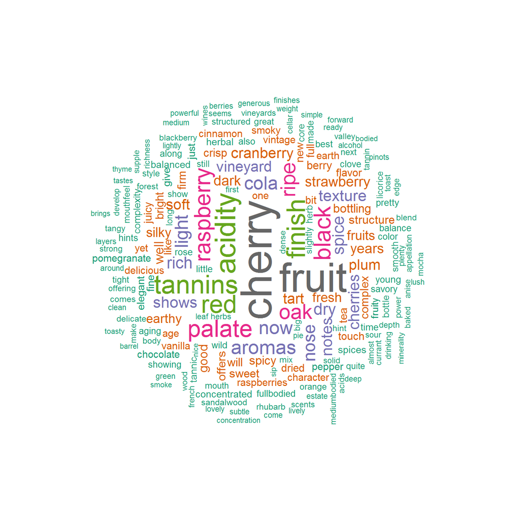

### Cabernet Sauvignon Words(Second most reviewed red wine)

```
##                  word freq
## tannins       tannins 3610
## black           black 3368
## fruit           fruit 3139
## cherry         cherry 2848
## finish         finish 2711
## aromas         aromas 2565
## oak               oak 2527
## blackberry blackberry 2390
## palate         palate 2104
## cassis         cassis 1680
```

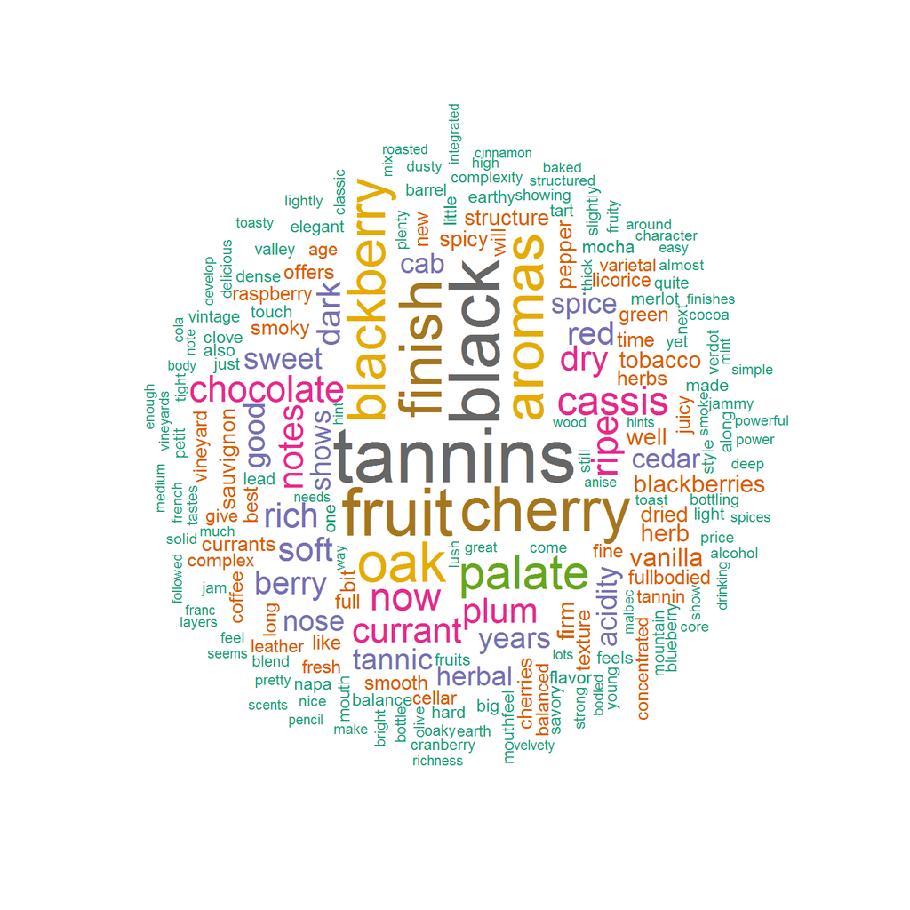

### Chardonnay Words(Most reviewed white wine)

```
##            word freq
## acidity acidity 4000
## apple     apple 3580
## fruit     fruit 3513
## finish   finish 2721
## oak         oak 2710
## palate   palate 2527
## ripe       ripe 2488
## aromas   aromas 2364
## pear       pear 2067
## lemon     lemon 2009
```

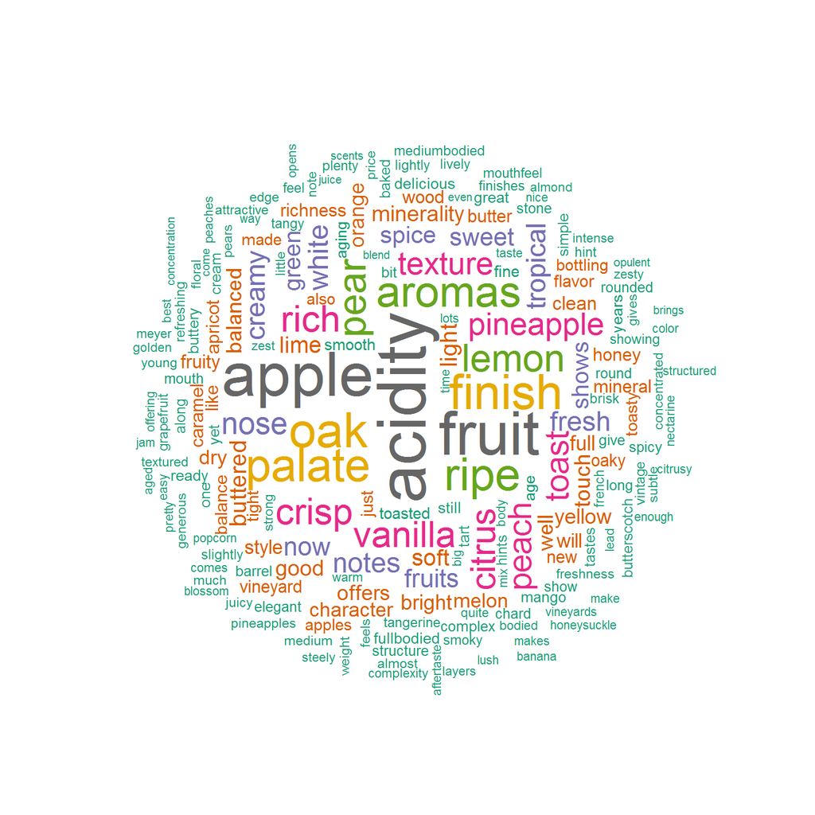

As we can see, there is a considerable difference in the words used to describe red wines as opposed to white wines.

## Regression model to predict the score a wine receives

#### Model 1:

Using `wordcount` to predict `points`

```
##
## Call:
## lm(formula = points ~ wordcount, data = new_data)
##
## Residuals:
##      Min       1Q   Median       3Q      Max
## -12.2893  -1.7557  -0.0108   1.8182  11.3078
##
## Coefficients:
##              Estimate Std. Error t value Pr(>|t|)
## (Intercept) 8.244e+01  3.092e-02  2666.1   <2e-16 ***
## wordcount   1.490e-01  7.311e-04   203.8   <2e-16 ***
## ---
## Signif. codes:  0 '***' 0.001 '**' 0.01 '*' 0.05 '.' 0.1 ' ' 1
##
## Residual standard error: 2.593 on 98237 degrees of freedom
## Multiple R-squared:  0.2971, Adjusted R-squared:  0.2971
## F-statistic: 4.152e+04 on 1 and 98237 DF,  p-value: < 2.2e-16
```

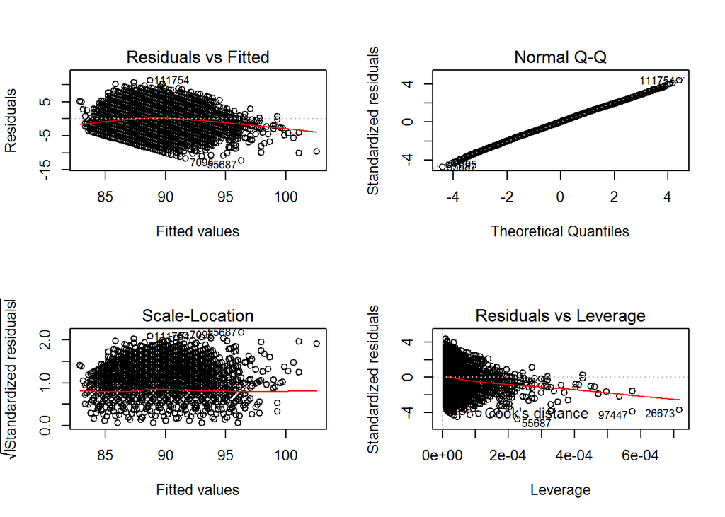

With a significant p-value, `wordcount` is a significant predictor of `points`. The linear model is significant, and has an adjusted-R^2 of 0.2971.

#### Model 2:

Using `wordcount` and `price` to predict `points`

```
##
## Call:
## lm(formula = points ~ wordcount + log(price), data = new_data)
##
## Residuals:
##      Min       1Q   Median       3Q      Max
## -11.7600  -1.4012   0.1117   1.5298   8.2316
##
## Coefficients:
##              Estimate Std. Error t value Pr(>|t|)
## (Intercept) 7.677e+01  3.839e-02  1999.5   <2e-16 ***
## wordcount   1.026e-01  6.574e-04   156.1   <2e-16 ***
## log(price)  2.256e+00  1.123e-02   200.8   <2e-16 ***
## ---
## Signif. codes:  0 '***' 0.001 '**' 0.01 '*' 0.05 '.' 0.1 ' ' 1
##
## Residual standard error: 2.183 on 98236 degrees of freedom
## Multiple R-squared:  0.5017, Adjusted R-squared:  0.5017
## F-statistic: 4.945e+04 on 2 and 98236 DF,  p-value: < 2.2e-16
```

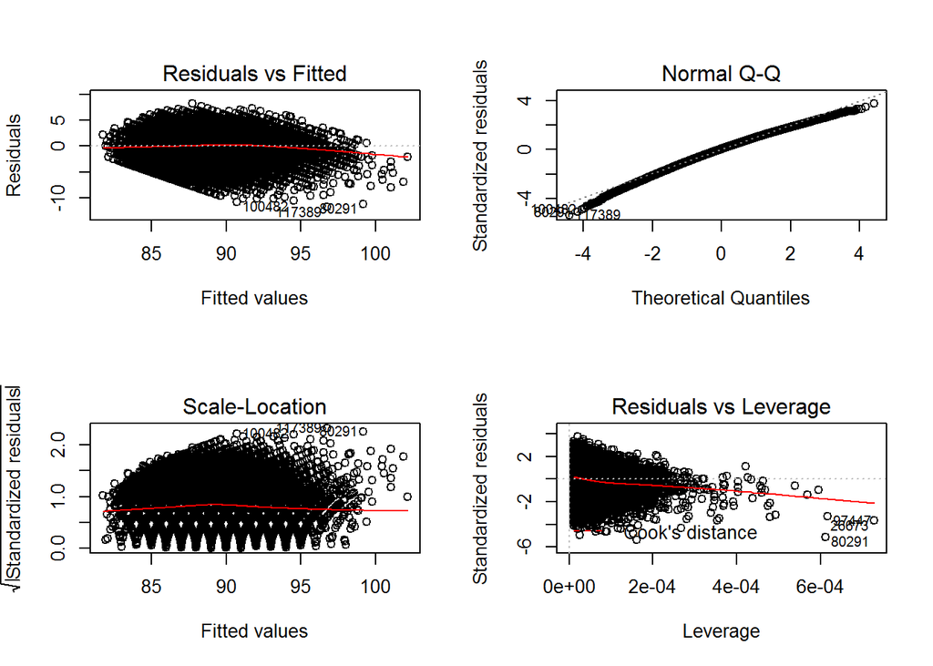

Including log(price) in our model increases the strength of the model, with an adjusted R^2 of 0.5017.

#### Model 3

Using `wordcount`, `price` and `variety` to predict `points`

```
##
## Call:
## lm(formula = points ~ wordcount + log(price) + variety, data = new_data)
##
## Residuals:
##      Min       1Q   Median       3Q      Max
## -13.3248  -1.3523   0.1048   1.4742   7.4753
##
## Coefficients:
##                                Estimate Std. Error  t value Pr(>|t|)
## (Intercept)                   76.093964   0.050856 1496.262  < 2e-16 ***
## wordcount                      0.102021   0.000645  158.176  < 2e-16 ***
## log(price)                     2.403076   0.012008  200.126  < 2e-16 ***
## varietyCabernet Franc         -0.351370   0.065415   -5.371 7.83e-08 ***
## varietyCabernet Sauvignon     -0.364018   0.036325  -10.021  < 2e-16 ***
## varietyChampagne Blend        -0.509277   0.067728   -7.519 5.55e-14 ***
## varietyChardonnay              0.358511   0.035394   10.129  < 2e-16 ***
## varietyGamay                   1.122329   0.079020   14.203  < 2e-16 ***
## varietyGewÃ¼rztraminer         0.794618   0.074495   10.667  < 2e-16 ***
## varietyGrÃ¼ner Veltliner       2.252202   0.069081   32.603  < 2e-16 ***
## varietyMalbec                 -0.059026   0.050848   -1.161 0.245712
## varietyMerlot                 -0.353973   0.048187   -7.346 2.06e-13 ***
## varietyNebbiolo                0.194600   0.053006    3.671 0.000241 ***
## varietyPetite Sirah           -0.164478   0.081759   -2.012 0.044249 *
## varietyPinot Grigio            0.162049   0.073476    2.205 0.027423 *
## varietyPinot Gris              1.110725   0.063974   17.362  < 2e-16 ***
## varietyPinot Noir              0.109912   0.034584    3.178 0.001483 **
## varietyPortuguese Red          1.579470   0.054048   29.223  < 2e-16 ***
## varietyPortuguese White        0.956523   0.074101   12.908  < 2e-16 ***
## varietyRed Blend              -0.192582   0.037046   -5.198 2.01e-07 ***
## varietyRhÃ´ne-style Red Blend  0.309599   0.063559    4.871 1.11e-06 ***
## varietyRiesling                1.431708   0.041869   34.195  < 2e-16 ***
## varietyRosÃ©                   0.316142   0.047689    6.629 3.39e-11 ***
## varietySangiovese             -0.141215   0.052263   -2.702 0.006893 **
## varietySauvignon Blanc         0.423687   0.042674    9.928  < 2e-16 ***
## varietyShiraz                  0.573246   0.079389    7.221 5.21e-13 ***
## varietySparkling Blend         0.179057   0.055345    3.235 0.001216 **
## varietySyrah                   0.375248   0.044027    8.523  < 2e-16 ***
## varietyTempranillo            -0.515842   0.058007   -8.893  < 2e-16 ***
## varietyViognier                0.220253   0.073566    2.994 0.002755 **
## varietyWhite Blend            -0.047446   0.054211   -0.875 0.381461
## varietyZinfandel              -0.121830   0.050044   -2.434 0.014916 *
## ---
## Signif. codes:  0 '***' 0.001 '**' 0.01 '*' 0.05 '.' 0.1 ' ' 1
##
## Residual standard error: 2.118 on 98207 degrees of freedom
## Multiple R-squared:  0.5311, Adjusted R-squared:  0.531
## F-statistic:  3589 on 31 and 98207 DF,  p-value: < 2.2e-16
```

[figure not shown]

Including the wine’s variety in model three provides the highest R-squared at 0.531. While some of the coefficients in variety aren’t statistically significant (*Malbec* and *White Blend* p-value >0.05), the rest of the varieties are significant.

### Findings and managerial implications

Data shows that certain pattern exist between wine variety and scores. We can quantify this relationship with our linear model.

Price is a very important factor, and generally the higher the price is, the higher review scores. Price has a long tail distribution, and a logarithm transformation would facilitate training of the model.

Most information reside in unstructured data, review description. In general, the more words the description has, the higher scores the product gets.

Our client can use our model to determine good product by looking at the coefficient values. Our client can use our model to predict scores of new products even when real scores are not available.